# Практика · Ієрархічна кластеризація та DBSCAN> Лекція: lecture.html · Тест: quiz.html · Домашнє: homework.mdУ темі 11 k-means провалився на трьох наборах даних: витягнутісмуги, вкладені кільця й дві групи різної щільності. Тут ми беремо ті самі три форми йдивимось, що з ними роблять два інші методи.Що зробимо:1. згенеруємо **три форми**, на яких k-means помиляється;2. напишемо **DBSCAN з нуля** й звіримо мітки з `sklearn` — вони мають збігтися точно;3. проженемо **три методи на трьох формах** і складемо таблицю з `adjusted_rand_score`;4. підберемо `eps` за **графіком відстані до k-го сусіда**;5. порівняємо **чотири звʼязки** ієрархічної кластеризації на тих самих даних;6. побудуємо **дендрограму** через `scipy.cluster.hierarchy`;7. прикладемо всі три методи до **справжньої дошки оголошень** і чесно звіримо результат із колонкою `шахрайське`, якої жоден алгоритм не бачив.Генератор випадкових чисел зафіксовано зерном 42 — числа у тебе будуть ті самі.

```python
import numpy as np
import pandas as pd
import matplotlib.pyplot as plt

from sklearn.preprocessing import StandardScaler
from sklearn.cluster import KMeans, DBSCAN, AgglomerativeClustering
from sklearn.neighbors import NearestNeighbors
from sklearn.metrics import adjusted_rand_score, precision_score, recall_score, f1_score
from scipy.cluster.hierarchy import linkage, dendrogram, fcluster

# зерно фіксує всю випадковість: у тебе вийдуть точно ті самі числа
rng = np.random.default_rng(42)

pd.set_option("display.width", 130)
pd.set_option("display.max_columns", 12)
print("numpy", np.__version__, "· pandas", pd.__version__)
```

```
numpy 2.5.1 · pandas 2.3.3
```

## 1 · Три форми, на яких k-means помиляєтьсяКожен набір робимо руками, щоб було видно, звідки береться форма:* **дві смуги** — точки на двох паралельних прямих із невеликим розкидом;* **вкладені кільця** — щільна купка в центрі й кільце навколо неї;* **різна щільність** — тісна купка й розсіяна хмара поруч.Правильні відповіді (`групи`) ми знаємо, бо самі їх задали. Жоден алгоритм їх не побачить —вони потрібні лише нам, щоб порівняти результати.

```python
def дві_смуги(скільки=65):
    # обидві смуги йдуть під нахилом 0.6, різниця тільки у зсуві по вертикалі
    зсув = 0.75
    x_верх = rng.uniform(-2.6, 2.6, скільки)
    y_верх = 0.6 * x_верх + зсув + rng.normal(0, 0.13, скільки)
    x_низ = rng.uniform(-2.6, 2.6, скільки)
    y_низ = 0.6 * x_низ - зсув + rng.normal(0, 0.13, скільки)
    точки = np.c_[np.r_[x_верх, x_низ], np.r_[y_верх, y_низ]]
    групи = np.r_[np.zeros(скільки, int), np.ones(скільки, int)]
    return точки, групи


def вкладені_кільця(внутрішніх=45, зовнішніх=85):
    # кут беремо рівномірно по колу, радіус — навколо 0.5 і навколо 2.0
    кут_всередині = rng.uniform(0, 2 * np.pi, внутрішніх)
    радіус_всередині = rng.normal(0.5, 0.12, внутрішніх)
    кут_ззовні = rng.uniform(0, 2 * np.pi, зовнішніх)
    радіус_ззовні = rng.normal(2.0, 0.13, зовнішніх)
    точки = np.c_[
        np.r_[радіус_всередині * np.cos(кут_всередині), радіус_ззовні * np.cos(кут_ззовні)],
        np.r_[радіус_всередині * np.sin(кут_всередині), радіус_ззовні * np.sin(кут_ззовні)]]
    групи = np.r_[np.zeros(внутрішніх, int), np.ones(зовнішніх, int)]
    return точки, групи


def різна_щільність(щільних=95, розсіяних=55):
    # розкид у другої групи втричі більший — саме це й зламає DBSCAN
    купка = rng.normal([-1.8, 0.0], [0.5, 0.7], (щільних, 2))
    хмара = rng.normal([1.0, -0.4], [1.5, 1.7], (розсіяних, 2))
    точки = np.vstack([купка, хмара])
    групи = np.r_[np.zeros(щільних, int), np.ones(розсіяних, int)]
    return точки, групи


форми = {
    "витягнуті смуги": дві_смуги(),
    "вкладені кільця": вкладені_кільця(),
    "різна щільність": різна_щільність(),
}
for назва, (точки, групи) in форми.items():
    print(f"{назва:16s} точок: {len(точки):3d}   групи: {np.bincount(групи)}")
```

```
витягнуті смуги  точок: 130   групи: [65 65]
вкладені кільця  точок: 130   групи: [45 85]
різна щільність  точок: 150   групи: [95 55]
```

Подивимось на них очима — саме так, як їх бачить людина й не бачить k-means.

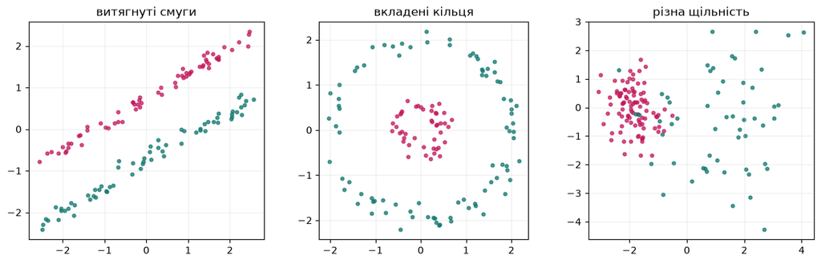

```
кольори — правильна відповідь, яку алгоритмам не показують
```

```python
фігура, осі = plt.subplots(1, 3, figsize=(12, 3.8))
for вісь, (назва, (точки, групи)) in zip(осі, форми.items()):
    for група, колір in [(0, "#c2185b"), (1, "#0f766e")]:
        обрані = групи == група
        вісь.scatter(точки[обрані, 0], точки[обрані, 1], s=12, color=колір, alpha=0.75)
    вісь.set_title(назва)
    вісь.set_aspect("equal")
    вісь.grid(alpha=0.2)
plt.tight_layout()
plt.show()
print("кольори — правильна відповідь, яку алгоритмам не показують")
```

## 2 · DBSCAN з нуляУвесь метод — це два числа й три ролі точки:* `eps` — радіус околу;* `min_samples` — скільки точок має бути в цьому радіусі (**разом із самою точкою**), щоб вона вважалась **ядерною**;* точка, у якої сусідів замало, але яка потрапила в чийсь чужий окіл, — **гранична**;* решта — **шум**, мітка `-1`.Далі алгоритм просто обходить точки: знайшов ядерну — відкрив кластер і розрісся по їїсусідах, і по сусідах тих сусідів, поки є куди рости.

```python
def dbscan_власний(точки, eps, min_samples):
    кількість = len(точки)
    мітки = np.full(кількість, -1)          # -1 = шум, поки не доведено інше
    відвідані = np.zeros(кількість, bool)

    # попарні відстані одразу для всіх: на кількох сотнях точок це дешево
    відстані = np.sqrt(((точки[:, None, :] - точки[None, :, :]) ** 2).sum(axis=2))
    сусіди = [np.flatnonzero(рядок <= eps) for рядок in відстані]

    номер_кластера = -1
    for старт in range(кількість):
        if відвідані[старт]:
            continue
        відвідані[старт] = True
        if len(сусіди[старт]) < min_samples:
            continue                        # не ядерна — поки що лишається шумом
        номер_кластера += 1
        мітки[старт] = номер_кластера
        черга = list(сусіди[старт])
        while черга:
            точка = черга.pop(0)
            if мітки[точка] == -1:
                мітки[точка] = номер_кластера   # гранична: забираємо її з шуму
            if відвідані[точка]:
                continue
            відвідані[точка] = True
            # кластер росте далі тільки через ядерні точки
            if len(сусіди[точка]) >= min_samples:
                черга.extend(сусіди[точка])
    return мітки


print("функція готова — 25 рядків, і це весь метод")
```

```
функція готова — 25 рядків, і це весь метод
```

Тепер найцінніша клітинка практики: всередині бібліотечного `DBSCAN` немає магії. Дамообом реалізаціям ті самі дані й ті самі параметри — мітки мають збігтися повністю.`adjusted_rand_score` дорівнює **1.0**, якщо два розбиття однакові з точністю доперейменування кластерів.

```python
для_звірки, _ = форми["вкладені кільця"]

наші_мітки = dbscan_власний(для_звірки, eps=0.6, min_samples=5)
бібліотечні = DBSCAN(eps=0.6, min_samples=5).fit_predict(для_звірки)

print("наші кластери:       ", np.bincount(наші_мітки[наші_мітки >= 0]))
print("кластери sklearn:    ", np.bincount(бібліотечні[бібліотечні >= 0]))
print("шумових у нас / у них:", int((наші_мітки == -1).sum()), "/", int((бібліотечні == -1).sum()))
print("збіг розбиттів (ARI): ", round(adjusted_rand_score(наші_мітки, бібліотечні), 6))

assert adjusted_rand_score(наші_мітки, бібліотечні) == 1.0, "розбиття розійшлись!"
assert ((наші_мітки == -1) == (бібліотечні == -1)).all(), "шум розійшовся!"
print("✅ збігається")
```

```
наші кластери:        [45 85]
кластери sklearn:     [45 85]
шумових у нас / у них: 0 / 0
збіг розбиттів (ARI):  1.0
✅ збігається
```

## 3 · Три методи на трьох формахУмови однакові для всіх, як і в лекції:* **k-means** — при `k = 2`, з десяти випадкових стартів;* **DBSCAN** — `eps = 0.6`, `min_samples = 5`: одні параметри на всі три набори;* **ієрархічна** — звʼязок Ворда (він стоїть за замовчуванням), дерево розрізане на дві групи.Міряємо `adjusted_rand_score` зі справжніми групами: **1.0** — ідеально, **0** — збіг нарівні випадкового перемішування.

```python
рядки = []
розбиття = {}
for назва, (точки, групи) in форми.items():
    мітки_kmeans = KMeans(n_clusters=2, n_init=10, random_state=42).fit_predict(точки)
    мітки_dbscan = DBSCAN(eps=0.6, min_samples=5).fit_predict(точки)
    мітки_ward = AgglomerativeClustering(n_clusters=2, linkage="ward").fit_predict(точки)
    розбиття[назва] = (мітки_kmeans, мітки_dbscan, мітки_ward)
    рядки.append({
        "набір": назва,
        "k-means": round(adjusted_rand_score(групи, мітки_kmeans), 3),
        "DBSCAN": round(adjusted_rand_score(групи, мітки_dbscan), 3),
        "ієрархічна (Ворд)": round(adjusted_rand_score(групи, мітки_ward), 3),
        "кластерів DBSCAN": len(set(мітки_dbscan[мітки_dbscan >= 0])),
        "шуму DBSCAN": int((мітки_dbscan == -1).sum()),
    })

таблиця_методів = pd.DataFrame(рядки)
print(таблиця_методів.to_string(index=False))
```

```
          набір  k-means  DBSCAN  ієрархічна (Ворд)  кластерів DBSCAN  шуму DBSCAN
витягнуті смуги    0.033   1.000              0.027                 2            0
вкладені кільця    0.023   1.000             -0.002                 2            0
різна щільність    0.677   0.637              0.701                 3           29
```

Читається таблиця так. На **смугах і кільцях** DBSCAN дає 1.0 — ідеально, — а k-means іВорд не дають нічого: їхній ARI майже нуль, тобто розбиття не краще за випадкове.На **різній щільності** порядок перевертається: Ворд найкращий, k-means трохи гірший, аDBSCAN відстає й половину розсіяної хмари викидає в шум.Тепер те саме очима — девʼять картинок.

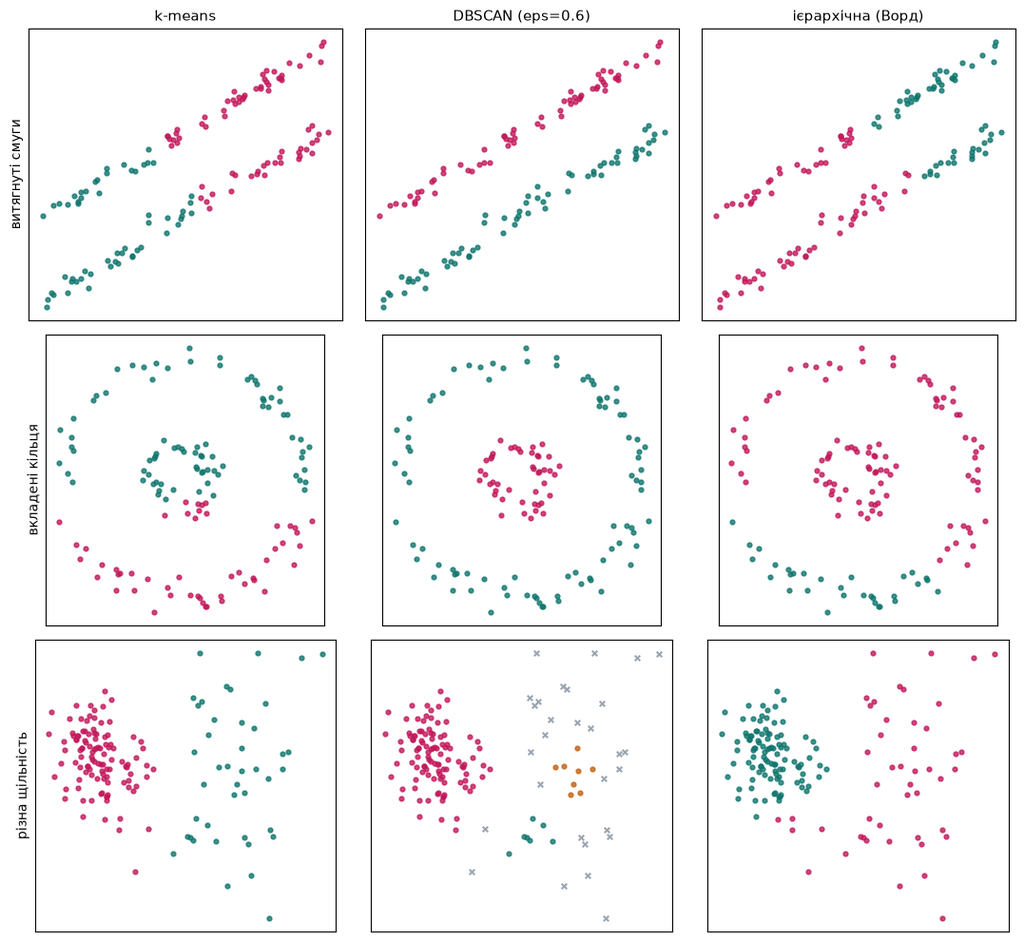

```
сірі хрестики — точки, які DBSCAN відніс до шуму
```

```python
фігура, осі = plt.subplots(3, 3, figsize=(11, 10))
назви_методів = ["k-means", "DBSCAN (eps=0.6)", "ієрархічна (Ворд)"]
палітра = ["#c2185b", "#0f766e", "#c2620f", "#5b3fa8", "#1d6fbf"]

for рядок, (назва, (точки, групи)) in enumerate(форми.items()):
    for стовпець, мітки in enumerate(розбиття[назва]):
        вісь = осі[рядок, стовпець]
        # шум малюємо сірими хрестиками, кластери — кольорами
        шум = мітки == -1
        вісь.scatter(точки[шум, 0], точки[шум, 1], s=16, marker="x", color="#9aa5b1")
        for номер in sorted(set(мітки[~шум])):
            обрані = мітки == номер
            вісь.scatter(точки[обрані, 0], точки[обрані, 1], s=12,
                         color=палітра[номер % len(палітра)], alpha=0.8)
        вісь.set_aspect("equal")
        вісь.set_xticks([]); вісь.set_yticks([])
        if рядок == 0:
            вісь.set_title(назви_методів[стовпець], fontsize=11)
        if стовпець == 0:
            вісь.set_ylabel(назва, fontsize=10)
plt.tight_layout()
plt.show()
print("сірі хрестики — точки, які DBSCAN відніс до шуму")
```

## 4 · Звідки брати `eps`Прийом стандартний: для кожної точки знайти відстань до її k-го найближчого сусіда(k беруть рівним `min_samples − 1`), відсортувати ці відстані й шукати **коліно** — місце,де крива з пологої різко йде вгору. Висота коліна і є розумний `eps`.Щоб було цікавіше, підкинемо до двох смуг **15 розкиданих одинаків** — точок, які неналежать жодній групі. Саме їх DBSCAN і має віднести до шуму.

```python
точки_смуг, групи_смуг = форми["витягнуті смуги"]

# одинак — точка, яка стоїть не ближче ніж 0.55 до будь-якої точки смуг
одинаки = []
while len(одинаки) < 15:
    кандидат = rng.uniform([-2.8, -2.6], [2.8, 2.8])
    до_смуг = np.hypot(точки_смуг[:, 0] - кандидат[0], точки_смуг[:, 1] - кандидат[1])
    if до_смуг.min() > 0.55:
        одинаки.append(кандидат)

смуги_з_шумом = np.vstack([точки_смуг, np.array(одинаки)])
номери_одинаків = set(range(len(точки_смуг), len(смуги_з_шумом)))
print("точок разом:", len(смуги_з_шумом), "· з них підкинутих одинаків:", len(номери_одинаків))
```

```
точок разом: 145 · з них підкинутих одинаків: 15
```

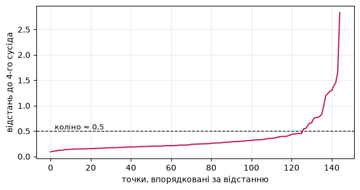

```
медіана: 0.241
вище 0.5: 19 точок зі 145
```

```python
# n_neighbors=5: перший «сусід» — сама точка, тому четвертий справжній сусід у стовпці 4
сусіди = NearestNeighbors(n_neighbors=5).fit(смуги_з_шумом)
відстані_до_сусідів, _ = сусіди.kneighbors(смуги_з_шумом)
четвертий_сусід = np.sort(відстані_до_сусідів[:, 4])

plt.figure(figsize=(7, 3.4))
plt.plot(четвертий_сусід, color="#c2185b")
plt.axhline(0.5, color="#17212b", linestyle="--", linewidth=1)
plt.text(2, 0.53, "коліно ≈ 0.5", fontsize=9)
plt.xlabel("точки, впорядковані за відстанню")
plt.ylabel("відстань до 4-го сусіда")
plt.grid(alpha=0.25)
plt.show()

print(f"медіана: {np.median(четвертий_сусід):.3f}")
print(f"вище 0.5: {int((четвертий_сусід > 0.5).sum())} точок зі {len(четвертий_сусід)}")
```

Тепер перевіримо коліно ділом: візьмемо `eps` з нього й подивимось, чи стануть шумом рівноті точки, які ми підкинули.

```python
мітки_з_коліна = DBSCAN(eps=0.5, min_samples=5).fit_predict(смуги_з_шумом)
знайдений_шум = set(np.flatnonzero(мітки_з_коліна == -1).tolist())

print("кластерів:", len(set(мітки_з_коліна[мітки_з_коліна >= 0])))
print("шумових точок:", len(знайдений_шум))
print("це рівно підкинуті одинаки:", знайдений_шум == номери_одинаків)
print("ARI на самих смугах:",
      round(adjusted_rand_score(групи_смуг, мітки_з_коліна[:len(точки_смуг)]), 3))
```

```
кластерів: 2
шумових точок: 15
це рівно підкинуті одинаки: True
ARI на самих смугах: 1.0
```

```python
точки_щільності, групи_щільності = форми["різна щільність"]

рядки = []
for eps in [0.3, 0.4, 0.5, 0.6, 0.8, 1.0, 1.2]:
    мітки = DBSCAN(eps=eps, min_samples=5).fit_predict(точки_щільності)
    рядки.append({"eps": eps,
                  "кластерів": len(set(мітки[мітки >= 0])),
                  "шуму": int((мітки == -1).sum()),
                  "ARI": round(adjusted_rand_score(групи_щільності, мітки), 3)})

перебір_eps = pd.DataFrame(рядки)
print(перебір_eps.to_string(index=False))

найкращий_dbscan = перебір_eps["ARI"].max()
ari_kmeans = таблиця_методів.loc[таблиця_методів["набір"] == "різна щільність", "k-means"].item()
ari_ward = таблиця_методів.loc[таблиця_методів["набір"] == "різна щільність", "ієрархічна (Ворд)"].item()
print(f"\nнайкращий DBSCAN: {найкращий_dbscan}   k-means: {ari_kmeans}   Ворд: {ari_ward}")
```

```
 eps  кластерів  шуму   ARI
 0.3          2    70 0.409
 0.4          1    56 0.636
 0.5          1    48 0.679
 0.6          3    29 0.637
 0.8          4    11 0.598
 1.0          2     7 0.656
 1.2          1     3 0.030

найкращий DBSCAN: 0.679   k-means: 0.677   Ворд: 0.701
```

На різній щільності коліна немає, і жодне значення `eps` не рятує: при малому радіусірозсіяна хмара майже вся йде в шум, при великому — зливається з купкою. Найкраще, щовдається витиснути, — приблизно рівень k-means і гірше за Ворда. Причому вибрати цезначення можна лише підглядаючи у правильну відповідь, якої в реальній задачі немає.## 5 · Чотири звʼязки ієрархічної кластеризації`linkage` відповідає на питання «що таке відстань між двома **групами**»:* `single` — між двома найближчими точками груп;* `complete` — між двома найдальшими;* `average` — середнє з усіх попарних відстаней;* `ward` — наскільки зросте сума квадратів усередині груп після злиття.Вибір міняє результат сильніше, ніж будь-що інше в методі.

```python
рядки = []
for назва, (точки, групи) in форми.items():
    рядок = {"набір": назва}
    for звʼязок in ["single", "complete", "average", "ward"]:
        мітки = AgglomerativeClustering(n_clusters=2, linkage=звʼязок).fit_predict(точки)
        менша_група = min(np.bincount(мітки))
        рядок[звʼязок] = round(adjusted_rand_score(групи, мітки), 3)
        рядок[звʼязок + " (менша)"] = менша_група
    рядки.append(рядок)

таблиця_звʼязків = pd.DataFrame(рядки)
print(таблиця_звʼязків.to_string(index=False))
```

```
          набір  single  single (менша)  complete  complete (менша)  average  average (менша)   ward  ward (менша)
витягнуті смуги    1.00              65     0.013                39    0.012               53  0.027            56
вкладені кільця    1.00              45    -0.040                24   -0.002               31 -0.002            31
різна щільність    0.01               1     0.655                41    0.677               42  0.701            47
```

```python
кількість = 1200

моделі = ["Alfa A5", "Alfa A7", "Beta 12", "Beta 12 Pro", "Gamma X", "Gamma X Ultra"]
ціна_нового = {"Alfa A5": 5200, "Alfa A7": 7400, "Beta 12": 12000,
               "Beta 12 Pro": 17500, "Gamma X": 24000, "Gamma X Ultra": 34000}
частки_моделей = [0.24, 0.22, 0.18, 0.16, 0.12, 0.08]

# ВАЖЛИВО: дошку генеруємо власним генератором із зерном 42, щоб числа збіглися
# з темами 22, 25 і 26 — вище ми вже витратили частину послідовності на форми
гсч_дошки = np.random.default_rng(42)

модель = гсч_дошки.choice(моделі, size=кількість, p=частки_моделей)
рік = гсч_дошки.integers(2017, 2025, size=кількість)
стан = гсч_дошки.choice(["нове", "дуже добре", "добре", "задовільне"],
                        size=кількість, p=[0.08, 0.32, 0.42, 0.18])
памʼять = гсч_дошки.choice([64, 128, 256, 512], size=кількість, p=[0.30, 0.38, 0.24, 0.08])
вік_акаунта = np.round(гсч_дошки.exponential(420, size=кількість) + 3).astype(int)

базова = np.array([ціна_нового[m] for m in модель])
знос = 0.82 ** (2024 - рік)
коефіцієнт_стану = np.array(
    [{"нове": 1.0, "дуже добре": 0.88, "добре": 0.75, "задовільне": 0.58}[s] for s in стан])
коефіцієнт_памʼяті = np.array(
    [{64: 0.85, 128: 1.0, 256: 1.15, 512: 1.32}[m] for m in памʼять])

типова_ціна_за_паспортом = базова * знос * коефіцієнт_стану * коефіцієнт_памʼяті
ціна = типова_ціна_за_паспортом * гсч_дошки.lognormal(0, 0.13, size=кількість)

шанс_шахрайства = 0.10 + 0.30 * np.exp(-вік_акаунта / 120)
шахрайське = гсч_дошки.random(кількість) < шанс_шахрайства
ставить_дешево = гсч_дошки.random(кількість) < 0.74
дешева_приманка = шахрайське & ставить_дешево
дорога_приманка = шахрайське & ~ставить_дешево
ціна[дешева_приманка] = (типова_ціна_за_паспортом[дешева_приманка]
                         * гсч_дошки.uniform(0.20, 0.45, дешева_приманка.sum()))
ціна[дорога_приманка] = (типова_ціна_за_паспортом[дорога_приманка]
                         * гсч_дошки.uniform(2.6, 3.8, дорога_приманка.sum()))
ціна = np.round(ціна, -1)
скарг = np.where(шахрайське, 1 + гсч_дошки.poisson(3.0, кількість),
                 гсч_дошки.poisson(0.03, кількість))

дошка = pd.DataFrame({
    "модель": модель, "рік": рік, "стан": стан, "памʼять_гб": памʼять,
    "вік_акаунта": вік_акаунта, "скарг": скарг, "ціна": ціна,
    "шахрайське": шахрайське.astype(int),
})

# ті самі шість неприємностей із теми 08
колекційні = дошка.index[дошка["модель"] == "Gamma X"][:4]
дошка.loc[колекційні, ["рік", "стан", "памʼять_гб"]] = [2017, "нове", 512]
дошка.loc[колекційні, "ціна"] = [82000.0, 88000.0, 91000.0, 95000.0]
дошка.loc[колекційні, ["шахрайське", "скарг"]] = 0

одруки = дошка.index[(дошка["ціна"] > 7000) & (дошка["ціна"] < 9600)
                     & (дошка["шахрайське"] == 0)][:2]
дошка.loc[одруки, "ціна"] = дошка.loc[одруки, "ціна"] * 10

памʼять_текстом = дошка["памʼять_гб"].astype(str)
із_одиницями = гсч_дошки.random(len(дошка)) < 0.18
памʼять_текстом[із_одиницями] = памʼять_текстом[із_одиницями] + " ГБ"
дошка["памʼять_гб"] = памʼять_текстом

ймовірність_пропуску = np.where(дошка["шахрайське"] == 1, 0.25, 0.03)
дошка.loc[гсч_дошки.random(len(дошка)) < ймовірність_пропуску, "ціна"] = np.nan
дошка.loc[гсч_дошки.random(len(дошка)) < 0.04, "стан"] = np.nan

повтори = гсч_дошки.choice(дошка.index, size=12, replace=False)
дошка = pd.concat([дошка, дошка.loc[повтори]], ignore_index=True)

print("таблиця як у темі 08:", дошка.shape)
assert дошка.shape == (1212, 8), "форма розійшлась із темою 22"
print("✅ форма збігається")
```

```
таблиця як у темі 08: (1212, 8)
✅ форма збігається
```

Далі — ті самі дві ознаки, що й у темі 11: **логарифм ціни** й **рік випуску**, обидвіприведені до z-оцінок. Обидва наші методи рахують відстані, тож без спільної шкали вонидивились би лише на ціну.

```python
ринок = дошка.drop_duplicates().reset_index(drop=True)
ринок["памʼять_гб"] = ринок["памʼять_гб"].astype(str).str.replace(" ГБ", "", regex=False).astype(int)
ринок = ринок.dropna(subset=["ціна"]).reset_index(drop=True)

ціни = ринок["ціна"].to_numpy(float)
роки = ринок["рік"].to_numpy(int)
шахрайське_справді = ринок["шахрайське"].to_numpy()

масштабувач = StandardScaler().fit(np.c_[np.log(ціни), роки])
масштабовані = масштабувач.transform(np.c_[np.log(ціни), роки])

print("оголошень для кластеризації:", len(ринок))
print("шахрайських серед них:", int(шахрайське_справді.sum()),
      f"({100 * шахрайське_справді.mean():.1f} %)")
print("розкид після масштабування:", масштабовані.std(axis=0).round(6))
```

```
оголошень для кластеризації: 1100
шахрайських серед них: 139 (12.6 %)
розкид після масштабування: [1. 1.]
```

### Дендрограма двадцяти восьми оголошеньДерево на 1 100 листків не читається, тому візьмемо випадкові 28 оголошень — ті самі, щов лекції. `scipy` малює дендрограму сам: висота перемички — відстань між групами в моментзлиття.

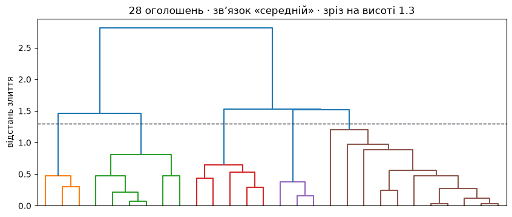

```
зріз 0.5 → груп: 12 · розміри: [6, 4, 3, 3, 2, 2, 2, 2, 1, 1, 1, 1]
зріз 0.9 → груп:  7 · розміри: [9, 6, 5, 3, 3, 1, 1]
зріз 1.3 → груп:  5 · розміри: [11, 6, 5, 3, 3]
зріз 1.6 → груп:  2 · розміри: [19, 9]
зріз 2.0 → груп:  2 · розміри: [19, 9]
зріз 3.0 → груп:  1 · розміри: [28]
```

```python
гсч_вибірки = np.random.default_rng(1)
вибрані = np.sort(гсч_вибірки.choice(len(масштабовані), 28, replace=False))
підвибірка = масштабовані[вибрані]

дерево = linkage(підвибірка, method="average")

plt.figure(figsize=(10, 4))
dendrogram(дерево, color_threshold=1.3, no_labels=True)
plt.axhline(1.3, color="#17212b", linestyle="--", linewidth=1)
plt.title("28 оголошень · звʼязок «середній» · зріз на висоті 1.3")
plt.ylabel("відстань злиття")
plt.show()

for висота in [0.5, 0.9, 1.3, 1.6, 2.0, 3.0]:
    групи_на_зрізі = fcluster(дерево, висота, criterion="distance")
    print(f"зріз {висота:.1f} → груп: {len(set(групи_на_зрізі)):2d} "
          f"· розміри: {sorted(np.bincount(групи_на_зрізі)[1:].tolist(), reverse=True)}")
```

Одне дерево — і скільки завгодно розбиттів. Кількість груп обираєш **після** побудови,дивлячись на висоти: між 1.6 і 2.8 нічого не змінюється, а це означає, що поділ на двігрупи тут стійкий.Подивимось, що це за групи, коли ріжемо на три.

```python
три_групи = fcluster(дерево, 3, criterion="maxclust")

опис = pd.DataFrame({
    "група": [f"група {c}" for c in sorted(set(три_групи))],
    "оголошень": [int((три_групи == c).sum()) for c in sorted(set(три_групи))],
    "медіанна ціна": [int(np.median(ціни[вибрані][три_групи == c])) for c in sorted(set(три_групи))],
    "медіанний рік": [int(np.median(роки[вибрані][три_групи == c])) for c in sorted(set(три_групи))],
})
print(опис.to_string(index=False))
```

```
  група  оголошень  медіанна ціна  медіанний рік
група 1          9          12920           2024
група 2          5           5400           2018
група 3         14           2045           2020
```

### DBSCAN на всій дошціТепер щільність на справжніх даних. Візьмемо `eps = 0.3` і `min_samples = 5` — і подивимосьне стільки на кластери, скільки на **шум**.

```python
мітки_дошки = DBSCAN(eps=0.3, min_samples=5).fit_predict(масштабовані)
шум = мітки_дошки == -1

print("кластерів:", len(set(мітки_дошки[~шум])))
print("розміри:", sorted(np.bincount(мітки_дошки[~шум]).tolist(), reverse=True))
print("шумових оголошень:", int(шум.sum()))
print("з них шахрайських:", int(шахрайське_справді[шум].sum()),
      f"({100 * шахрайське_справді[шум].mean():.1f} %)")
print("\nціни шумових оголошень, грн:")
print(np.sort(ціни[шум]).astype(int))
```

```
кластерів: 12
розміри: [157, 144, 138, 137, 123, 120, 118, 112, 7, 7, 6, 5]
шумових оголошень: 26
з них шахрайських: 25 (96.2 %)

ціни шумових оголошень, грн:
[  130   190   200   290   290   330   360   370   390   420   420   430
   550   590   730   850   880 13130 15010 20280 27960 38570 45320 52620
 59840 83500]
```

Шум DBSCAN — це майже чисті шахраї: ціни-приманки по 130–880 грн і завищені десятки тисяч.Порахуємо це як детектор тими самими метриками, що й утемі 05, і порівняємо з двома попередніми спробами.

```python
прогноз_за_шумом = шум.astype(int)

print(f"precision: {precision_score(шахрайське_справді, прогноз_за_шумом):.3f}")
print(f"recall:    {recall_score(шахрайське_справді, прогноз_за_шумом):.3f}")
print(f"F1:        {f1_score(шахрайське_справді, прогноз_за_шумом):.3f}")
print("\nдля порівняння:")
print("  найдешевший кластер k-means (тема 11): F1 = 0.296")
print("  модель із учителем (тема 29):          F1 = 0.796")
```

```
precision: 0.962
recall:    0.180
F1:        0.303

для порівняння:
  найдешевший кластер k-means (тема 11): F1 = 0.296
  модель із учителем (тема 29):          F1 = 0.796
```

Точність майже ідеальна, повнота мізерна: DBSCAN ловить лише тих шахраїв, які виставилигеть дику ціну. Звичайний шахрай сидить у гущі оголошень, і жодна щільність його невідрізнить — саме тому в темі 29 довелось будувати ознаку «ціна відносно типової».А тепер обіцяна чесність про 12 кластерів: це не сегменти ринку.

```python
крок_між_роками = 1 / роки.std()
print(f"один рік у z-оцінках = {крок_між_роками:.3f}")
print("а eps ми взяли 0.3 — менше, ніж відстань між сусідніми роками\n")

for eps in [0.2, 0.3, 0.45, 0.5, 0.6]:
    мітки = DBSCAN(eps=eps, min_samples=5).fit_predict(масштабовані)
    розміри = sorted(np.bincount(мітки[мітки >= 0]).tolist(), reverse=True)
    print(f"eps={eps:.2f}: кластерів {len(розміри):2d}, шум {int((мітки == -1).sum()):3d}, "
          f"найбільший {розміри[0] if розміри else 0}")
```

```
один рік у z-оцінках = 0.433
а eps ми взяли 0.3 — менше, ніж відстань між сусідніми роками

eps=0.20: кластерів 12, шум  44, найбільший 157
```

```
eps=0.30: кластерів 12, шум  26, найбільший 157
eps=0.45: кластерів  3, шум   9, найбільший 1077
```

```
eps=0.50: кластерів  2, шум   6, найбільший 1089
eps=0.60: кластерів  2, шум   1, найбільший 1094
```

Ось і вся відповідь DBSCAN про дошку: поки радіус менший за відстань між роками, він ріжедані на горизонтальні смуги «всі оголошення 2019 року»; щойно радіус її перевищує — усядошка стає одним кластером. Проміжного варіанта немає, бо **щільнісно відокремлених групна цій дошці не існує**.### Ієрархічна на всій дошціОстанній крок: чотири звʼязки на 1 100 оголошеннях, три групи. Тут добре видноланцюжковий ефект.

```python
рядки = []
for звʼязок in ["single", "complete", "average", "ward"]:
    мітки = AgglomerativeClustering(n_clusters=3, linkage=звʼязок).fit_predict(масштабовані)
    рядки.append({
        "звʼязок": звʼязок,
        "розміри груп": sorted(np.bincount(мітки).tolist(), reverse=True),
        "ARI з шахрайством": round(adjusted_rand_score(шахрайське_справді, мітки), 4),
    })

порівняння_звʼязків = pd.DataFrame(рядки)
print(порівняння_звʼязків.to_string(index=False))

мітки_kmeans = KMeans(n_clusters=3, n_init=10, random_state=42).fit_predict(масштабовані)
мітки_ward = AgglomerativeClustering(n_clusters=3, linkage="ward").fit_predict(масштабовані)
print(f"\nARI між k-means і Вордом на дошці: {adjusted_rand_score(мітки_kmeans, мітки_ward):.3f}")
print("розміри k-means:", sorted(np.bincount(мітки_kmeans).tolist(), reverse=True))
```

```
 звʼязок    розміри груп  ARI з шахрайством
  single    [1094, 5, 1]             0.0029
complete  [656, 433, 11]             0.0156
 average    [1089, 8, 3]             0.0420
    ward [439, 360, 301]            -0.0025
```

```
ARI між k-means і Вордом на дошці: 0.353
розміри k-means: [481, 355, 264]
```

Одиночний і середній звʼязки дали безглузді розбиття: один велетень і дві порошинки —класичний ланцюжковий ефект на реальних даних. Ворд дав співмірні групи, але навіть вінне збігається з k-means: ARI близько 0.35, тобто **це помітно інші сегменти**, хоч обидваметоди мінімізують ту саму суму квадратів.І жоден із методів не має нічого спільного з колонкою `шахрайське` — ARI біля нуля. Це непоразка: кластеризація знаходить те, що є в геометрії даних, а не те, що нам цікаво.---## Завдання### 🟢 Рівень 1 — БазаДодай до трьох форм четверту — **два півмісяці** (у `sklearn` це`datasets.make_moons(n_samples=200, noise=0.06, random_state=42)`) і прожени на ній усітри методи так само, як у розділі 3.Що має бути в результаті: рядок таблиці з трьома значеннями ARI й одне речення про те,який метод переміг і чому саме він.### 🟡 Рівень 2 — ПлюсДосліди, наскільки вузька «смужка правильних відповідей» у DBSCAN. Для набору**«вкладені кільця»** побудуй сітку: `eps` від 0.2 до 1.2 з кроком 0.05, `min_samples` від3 до 10. Для кожної пари порахуй ARI зі справжніми групами й намалюй теплову карту(`plt.imshow`).Питання, на які треба відповісти числами: скільки пар із сітки дають ARI вище 0.95? Якачастка це від усієї сітки? Чи є серед них суцільна область, чи вони розкидані?### 🔴 Рівень 3 — ВикликРеалізуй **агломеративну кластеризацію з нуля** для звʼязків `single` і `complete`:1. почни з матриці попарних відстаней і списку груп, у кожній по одній точці;2. знайди дві найближчі групи, злий їх, запиши висоту злиття;3. перерахуй відстані від нової групи до решти (для `single` — мінімум із двох, для `complete` — максимум);4. повтори, поки не лишиться одна група.Порівняй свої мітки з `AgglomerativeClustering` на всіх трьох формах при `n_clusters=2`.Зроблено, якщо `adjusted_rand_score` між твоїм і бібліотечним розбиттям дорівнює 1.0 дляобох звʼязків на всіх трьох наборах — і якщо ти можеш пояснити одним реченням, чому`single` і `complete` можна рахувати на звичайних відстанях, а Ворда — ні.